# R Notebook

```r
library(dplyr)
library(ggplot2)
library(ggrepel)
library(reshape2)
library(rtracklayer)
library(shiny)
source('~/HexamerBias/artificial_coverage/compare_peaks.r')
```

#### DENSITY FOR TARGETED SEQUENCING

Suppose we want to capture CTCF sites.

```bash
cat ../annotations_bed/CTCF_intestine_mm10.srt.bed |
bedtools flank -i stdin -g ../../genomes/mm10/mm10.genome -b 500 |
cut -f 1,2,3,4 |
bedtools groupby -g 1,4 -c 2,3 -o min,max |
awk '{print $1, $3, $4}' |
tr ' ' '\t' > CTCF.flank.bed

bedtools getfasta -fi /hpc/hub_oudenaarden/edann/genomes/mm10/mm10.fa -bed CTCF.flank.bed -fo CTCF.flank.fa
```

I assume that having a probability density proportional to the kmer abundance in the region of interest would boost coverage in that particular region. But is this true?

1. Counting kmers in the regions flanking CTCF sites

```bash
/hpc/hub_oudenaarden/edann/bin/coverage_bias/kmerCounter.py CTCF.flank.fa > CTCF.flank.kmers.txt
tail -n+2 CTCF.flank.kmers.txt > CTCF.flank.kmers.tab
cat CTCF.flank.kmers.tab | tail -n+2 | tr '\t' ','> CTCF.flank.kmers.csv
```

2. Correlating with total kmer abundance in the genome

|  | kmer | abundance.ctcf | abundance.tot | frac.ctcf | frac.tot | ratio.ctcf.tot |
| --- | --- | --- | --- | --- | --- | --- |
| 1 | CGCCGC | 7128 | 47345 | 0.02670906 | 0.001784731 | 14.96531 |
| 2 | GCGGCG | 6903 | 46741 | 0.02586597 | 0.001761963 | 14.68020 |
| 3 | GCCGCG | 4935 | 34246 | 0.01849175 | 0.001290948 | 14.32417 |
| 4 | CGCGGC | 4898 | 34058 | 0.01835311 | 0.001283861 | 14.29525 |
| 5 | GCGCGG | 5218 | 38409 | 0.01955217 | 0.001447877 | 13.50402 |
| 6 | GGCGCG | 4759 | 35666 | 0.01783227 | 0.001344476 | 13.26336 |

G and C rich sequences are overreppresented compared to the total genome abundance.

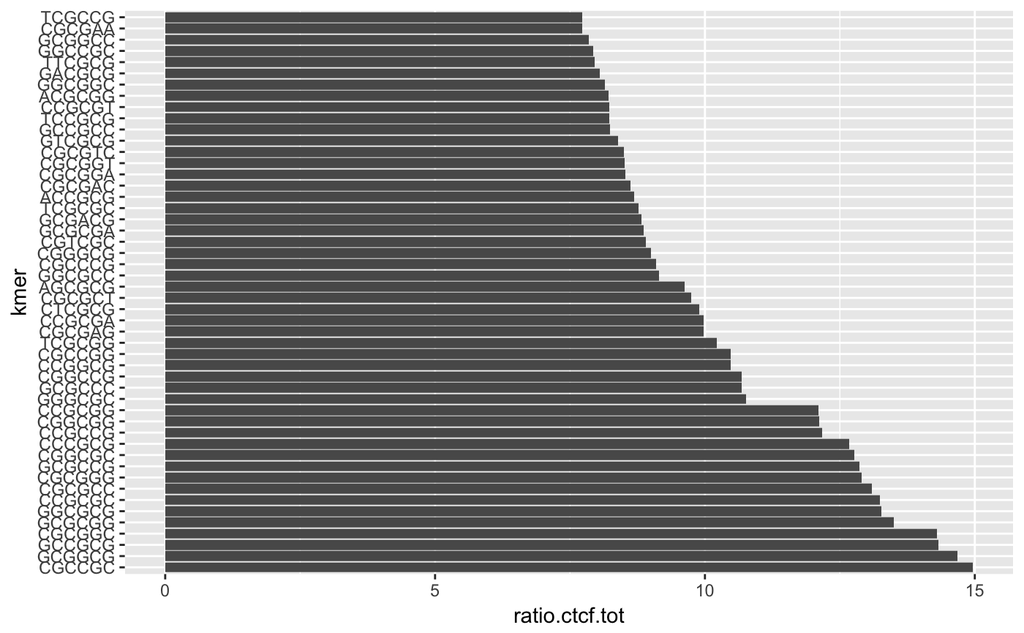

3. Compute coverage for density proportional to the kmer abundance in the flanks of CTCF sites, with function `coverage_prop_to_kmer_abundance` in module `optimization/primerProbability`
4. Compute predicted coverage profile with computed binding events

## Where are the CTCF sites?

```r
ctcf.track <- DataTrack(ctcf,
                        chromosome=chrom)
```

```
Error in DataTrack(ctcf, chromosome = chrom) :
  The strand has to be unique for all ranges in a DataTrack object.
```

## Real artificial coverage

```r
ctcf.bw.file <- '~/mnt/edann/hexamers/strand_specific/artificial_coverage/highcov.random.42CTCF.flank.propCov.artCov.bw'
norm.bw.file <- '~/mnt/edann/hexamers/strand_specific/artificial_coverage/highcov.random.42.artCov.bw'
ctcf.bw <- import(ctcf.bw.file, format = 'BigWig')
load.profile <- function(profile.txt, normalize=TRUE){
  profile <- scan(profile.txt)
  if (normalize) {
    return(profile/sum(profile))
  }
  else {
    return(profile)
  }
  }
ranges <- GRanges(seqnames = ctcf.bw@seqnames,
                  ranges = IRanges(start=ctcf.bw@ranges@start,
                                   end = ctcf.bw@ranges@start+1))
norm.bw <- import(norm.bw.file, format = 'BigWig', which = ranges)
```

```
restarting interrupted promise evaluation
```

```r
predcov.bw
```

```
GRanges object with 25095000 ranges and 3 metadata columns:
             seqnames                 ranges strand |      ctcf      norm                           id
                <Rle>              <IRanges>  <Rle> | <numeric> <numeric>                  <character>
         [1]     chr1     [3690001, 3690001]      * |  3.590178  3.881512     chr1 (3.66e+06,3.72e+06]
         [2]     chr1     [3690002, 3690002]      * |  3.591383  3.882690     chr1 (3.66e+06,3.72e+06]
         [3]     chr1     [3690003, 3690003]      * |  3.593791  3.885046     chr1 (3.66e+06,3.72e+06]
         [4]     chr1     [3690004, 3690004]      * |  3.597399  3.888579     chr1 (3.66e+06,3.72e+06]
         [5]     chr1     [3690005, 3690005]      * |  3.602201  3.893283     chr1 (3.66e+06,3.72e+06]
         ...      ...                    ...    ... .       ...       ...                          ...
  [25094996]     chrX [169264996, 169264996]      * |  6.079861  4.455332 chrX (1.6926e+08,1.6973e+08]
  [25094997]     chrX [169264997, 169264997]      * |  6.072497  4.449732 chrX (1.6926e+08,1.6973e+08]
  [25094998]     chrX [169264998, 169264998]      * |  6.066964  4.445523 chrX (1.6926e+08,1.6973e+08]
  [25094999]     chrX [169264999, 169264999]      * |  6.063270  4.442714 chrX (1.6926e+08,1.6973e+08]
  [25095000]     chrX [169265000, 169265000]      * |  6.061421  4.441308 chrX (1.6926e+08,1.6973e+08]
  -------
  seqinfo: 66 sequences from an unspecified genome
```

```r
ctcf.ovs <- findOverlaps(predcov.bw,ctcf)
```

```
Error in findOverlaps(predcov.bw, ctcf) : object 'ctcf' not found
```

The profiles are very similar but in some cases the proportional one is higher at CTCF sites.

```r
lapply(sample(regionsWctcf,10), function(x) plot.cov.wAnnotation(l.predcov.bw[x][[1]], ctcf))
```

[output not shown]

Is the difference in predicted coverage around CTCF sites significant using the density proportional to the kmer abundance around CTCF sites?

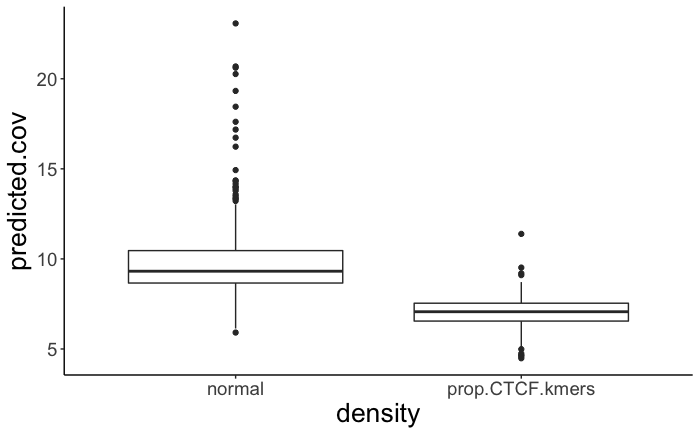

Is it significantly higher than the real coverage I get with equal amounts of primers?

```r
exp.bw.file <- '~/mnt/edann/hexamers/strand_specific/VAN1667_se.highcov42.bedGraph'
exp.bw <- import(exp.bw.file, format = 'bedGraph', which = ranges)
exp.bw.base <- make.base.res.bw(exp.bw)
ctcfreal.bw <- make.predVSexp.range(exp.bw = ctcf.bw, pred.bw = exp.bw.base)
colnames(mcols(ctcfreal.bw)) <- c('CTCF.cov','real.cov')
ctcfreal.bw  <- add.id(ctcfreal.bw )
ctcfreal.bw
```

```r
real.ovs <- findOverlaps(ctcfreal.bw, ctcf)
real.cov <- normalize.coverage(ctcfreal.bw[queryHits(real.ovs)])
t.test(real.cov$real.cov, ctcf.cov$norm, alternative = 'less')

as.data.frame(values(real.cov)) %>%
  # rename(prop.CTCF.kmers=ctcf,
         # normal=norm) %>%
  melt(id.vars='id', value.name='predicted.cov', variable.name='density') %>%
# pval.df <- compare_means(mean.cov ~ spear.group, data=cov.cor.clean, method='t.test') %>%
#   mutate(y.pos=6e-07)
ggplot(., aes(density,predicted.cov)) +
  geom_boxplot() +
  theme_classic() +
  theme(axis.title = element_text(size = 20), axis.text = element_text(size=14), title = element_text(size=22))
```

[output not shown]

Wops.

## Smaller flank

|  | kmer | abundance.ctcf | abundance.tot | frac.ctcf | frac.tot | ratio.ctcf.tot |
| --- | --- | --- | --- | --- | --- | --- |
| 1 | GCGCCC | 3546 | 71287 | 0.06760913 | 0.002688486 | 25.14765 |
| 2 | GGGCGC | 3494 | 71425 | 0.06661768 | 0.002693691 | 24.73100 |
| 3 | GGCGCC | 3210 | 77713 | 0.06120285 | 0.002930834 | 20.88240 |
| 4 | GCCGCG | 1252 | 34246 | 0.02387102 | 0.001291539 | 18.48262 |
| 5 | CGCCGC | 1726 | 47345 | 0.03290845 | 0.001785548 | 18.43044 |
| 6 | CGCGCC | 1279 | 35205 | 0.02438581 | 0.001327706 | 18.36688 |

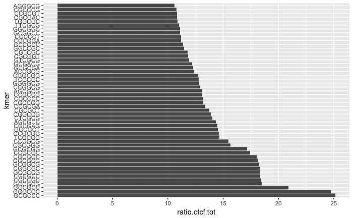

G and C rich sequences are overreppresented compared to the total genome abundance.

[output not shown]

More imbalance towards CG rich sequences

# Questions:

- How to reduce off target effects?

## How much does a small change in primer concentration affect the total coverage profile?

Compute the predicted coverage for little changes in base composition in one base (see `artCov_primer_variation.py` in folder `artificial_coverage`)

[figure not shown]

Normalize

```r
multicov <- data.frame(multicov[1], apply(multicov[-1],2,function(x) x/sum(x)))
head(multicov)
```

```r
long.multicov <- melt(multicov, id.vars='genomic.coord', variable.name='frac', value.name='predicted.cov') %>%
          mutate(fraction = as.numeric(gsub(frac, pattern='.+_frac', replacement = '')),
                 base = gsub(frac, pattern='_frac.+', replacement = ''))
long.multicov %>%
  filter(base=='C') %>%
  ggplot(., aes(genomic.coord, predicted.cov, group=fraction, color=fraction)) +
  geom_line() +
  theme_bw() +
  # ylim(0, 0.00040) +
  theme(axis.title = element_text(size = 20), axis.text = element_text(size=10), title = element_text(size=22), legend.text=element_text(size=14))
```

[output not shown]

## Shiny app

Same thing but interactive!

```
Listening on http://127.0.0.1:5915
```